# Artificial Intelligence Course, Dr.Fadaei

# CA#5 Feed Forward Neural Network

## Parnian Fazel 810198516

### Goal & Brief Description

In this assignment we are to implement **Feed Forward** neural networks to classify images. I will implement a Feed Forward neural network from scratch using the `Numpy` library. We are provided with an incomplete network implementation notebook that I should use. Then with the help of the given codes, I will train some neural networks on the given datas and see the effect of some parameters in the learning process. The data set includes images of 2 different classes of cats and horses. This dataset contains 32x32 pixel images, for each class there are 5000 images in the dataset.

## Importing Libraries

```python
import numpy as np
import pandas as pd
%matplotlib inline
import matplotlib.pyplot as plt
from collections import Counter
from matplotlib import image
from matplotlib import pyplot
import matplotlib.image as mpimg
import os
from PIL import Image
import cv2
from sklearn.model_selection import train_test_split

pd.options.display.max_rows;
```

## Loading Data

```python
img_df = pd.DataFrame(columns = range(0,1025))

path = "./data/"
dir_list = os.listdir(path)
num_dir_list = [int(x.split('.')[0]) for x in dir_list]
num_dir_list.sort()

for imgPath in num_dir_list:
    r = [None] * 1025
    gray = cv2.imread("./data/"+f'{imgPath}' + '.png', cv2.IMREAD_GRAYSCALE)
    r[0] = imgPath
    r[1:1025] = gray.flatten()
    img_df.loc[len(img_df)] = r
img_df.iloc[:, 1:1025] = img_df.iloc[:, 0:1025].astype(float)
img_df.set_index(0, inplace=True)
img_df.head(10)
```

| 0 | 1 | 2 | 3 | 4 | 5 | 6 | 7 | 8 | 9 | 10 | ... | 1015 | 1016 | 1017 | 1018 | 1019 | 1020 | 1021 | 1022 | 1023 | 1024 |
| --- | --- | --- | --- | --- | --- | --- | --- | --- | --- | --- | --- | --- | --- | --- | --- | --- | --- | --- | --- | --- | --- |
| 8 | 33 | 33 | 41 | 75 | 76 | 43 | 41 | 56 | 69 | 77 | ... | 119 | 113 | 136 | 140 | 131 | 149 | 152 | 127 | 125 | 123 |
| 10 | 123 | 102 | 92 | 99 | 100 | 136 | 171 | 170 | 142 | 92 | ... | 107 | 108 | 109 | 112 | 113 | 116 | 118 | 120 | 120 | 120 |
| 12 | 147 | 171 | 168 | 172 | 200 | 212 | 196 | 135 | 119 | 133 | ... | 155 | 151 | 124 | 75 | 69 | 122 | 134 | 131 | 132 | 134 |
| 13 | 203 | 200 | 200 | 201 | 200 | 201 | 202 | 202 | 201 | 201 | ... | 152 | 148 | 145 | 145 | 145 | 144 | 138 | 138 | 139 | 137 |
| 18 | 104 | 135 | 144 | 130 | 81 | 55 | 48 | 51 | 52 | 53 | ... | 70 | 69 | 64 | 62 | 63 | 58 | 54 | 48 | 47 | 50 |
| 22 | 84 | 88 | 83 | 79 | 78 | 78 | 72 | 76 | 81 | 88 | ... | 139 | 141 | 138 | 131 | 124 | 135 | 138 | 133 | 130 | 119 |
| 27 | 90 | 84 | 78 | 86 | 104 | 121 | 133 | 136 | 143 | 149 | ... | 44 | 29 | 23 | 12 | 11 | 28 | 70 | 110 | 121 | 126 |
| 34 | 5 | 5 | 4 | 5 | 7 | 7 | 13 | 21 | 12 | 4 | ... | 142 | 156 | 141 | 136 | 130 | 121 | 110 | 82 | 72 | 118 |
| 37 | 129 | 111 | 194 | 220 | 213 | 211 | 207 | 202 | 196 | 192 | ... | 166 | 186 | 202 | 219 | 226 | 228 | 227 | 223 | 221 | 220 |
| 38 | 104 | 96 | 95 | 98 | 101 | 102 | 100 | 107 | 114 | 114 | ... | 90 | 86 | 88 | 90 | 90 | 93 | 94 | 95 | 97 | 101 |

10 rows × 1024 columns

As we can see the range of pixels are between 0 and 255.

### Normalization

Unscaled input variables can result in a **slow** or **unstable** learning process, whereas unscaled target variables on regression problems can result in exploding gradients causing the learning process to **fail**. Differences in the scales across input variables may increase the difficulty of the problem being modeled. A target variable with a large spread of values, may result in **large error gradient** values causing weight values to change dramatically, making the learning process unstable.

To sum up it is beneficial in many cases. It improves the numerical **stability** of the model and often **reduces** training **time**.

```python
img_df_normalized=(img_df-img_df.min())/(img_df.max()-img_df.min())
img_df_normalized.head(10)
```

| 0 | 1 | 2 | 3 | 4 | 5 | 6 | 7 | 8 | 9 | 10 | ... | 1015 | 1016 | 1017 | 1018 | 1019 | 1020 | 1021 | 1022 | 1023 | 1024 |
| --- | --- | --- | --- | --- | --- | --- | --- | --- | --- | --- | --- | --- | --- | --- | --- | --- | --- | --- | --- | --- | --- |
| 8 | 0.129412 | 0.129412 | 0.160784 | 0.294118 | 0.298039 | 0.168627 | 0.160784 | 0.219608 | 0.270588 | 0.301961 | ... | 0.466667 | 0.443137 | 0.533333 | 0.54902 | 0.513725 | 0.584314 | 0.596078 | 0.498039 | 0.490196 | 0.482353 |
| 10 | 0.482353 | 0.4 | 0.360784 | 0.388235 | 0.392157 | 0.533333 | 0.670588 | 0.666667 | 0.556863 | 0.360784 | ... | 0.419608 | 0.423529 | 0.427451 | 0.439216 | 0.443137 | 0.454902 | 0.462745 | 0.470588 | 0.470588 | 0.470588 |
| 12 | 0.576471 | 0.670588 | 0.658824 | 0.67451 | 0.784314 | 0.831373 | 0.768627 | 0.529412 | 0.466667 | 0.521569 | ... | 0.607843 | 0.592157 | 0.486275 | 0.294118 | 0.270588 | 0.478431 | 0.52549 | 0.513725 | 0.517647 | 0.52549 |
| 13 | 0.796078 | 0.784314 | 0.784314 | 0.788235 | 0.784314 | 0.788235 | 0.792157 | 0.792157 | 0.788235 | 0.788235 | ... | 0.596078 | 0.580392 | 0.568627 | 0.568627 | 0.568627 | 0.564706 | 0.541176 | 0.541176 | 0.545098 | 0.537255 |
| 18 | 0.407843 | 0.529412 | 0.564706 | 0.509804 | 0.317647 | 0.215686 | 0.188235 | 0.2 | 0.203922 | 0.207843 | ... | 0.27451 | 0.270588 | 0.25098 | 0.243137 | 0.247059 | 0.227451 | 0.211765 | 0.188235 | 0.184314 | 0.196078 |
| 22 | 0.329412 | 0.345098 | 0.32549 | 0.309804 | 0.305882 | 0.305882 | 0.282353 | 0.298039 | 0.317647 | 0.345098 | ... | 0.545098 | 0.552941 | 0.541176 | 0.513725 | 0.486275 | 0.529412 | 0.541176 | 0.521569 | 0.509804 | 0.466667 |
| 27 | 0.352941 | 0.329412 | 0.305882 | 0.337255 | 0.407843 | 0.47451 | 0.521569 | 0.533333 | 0.560784 | 0.584314 | ... | 0.172549 | 0.113725 | 0.0901961 | 0.0470588 | 0.0431373 | 0.109804 | 0.27451 | 0.431373 | 0.47451 | 0.494118 |
| 34 | 0.0196078 | 0.0196078 | 0.0156863 | 0.0196078 | 0.027451 | 0.027451 | 0.0509804 | 0.0823529 | 0.0470588 | 0.0156863 | ... | 0.556863 | 0.611765 | 0.552941 | 0.533333 | 0.509804 | 0.47451 | 0.431373 | 0.321569 | 0.282353 | 0.462745 |
| 37 | 0.505882 | 0.435294 | 0.760784 | 0.862745 | 0.835294 | 0.827451 | 0.811765 | 0.792157 | 0.768627 | 0.752941 | ... | 0.65098 | 0.729412 | 0.792157 | 0.858824 | 0.886275 | 0.894118 | 0.890196 | 0.87451 | 0.866667 | 0.862745 |
| 38 | 0.407843 | 0.376471 | 0.372549 | 0.384314 | 0.396078 | 0.4 | 0.392157 | 0.419608 | 0.447059 | 0.447059 | ... | 0.352941 | 0.337255 | 0.345098 | 0.352941 | 0.352941 | 0.364706 | 0.368627 | 0.372549 | 0.380392 | 0.396078 |

10 rows × 1024 columns

```python
img_df.to_csv('ImagesData.csv')
```

```python
# img_df_ = pd.read_csv(r"ImagesData.csv")
# img_df_.iloc[:, 1:1025] = img_df_.iloc[:, 0:1025].astype(float)
# img_df_.set_index('0', inplace=True)
```

```python
labels_df = pd.read_csv(r"labels.csv")
labels_df.set_index("id", inplace=True)
labels_df.head(10)
```

| id | label |
| --- | --- |
| 8 | horse |
| 10 | cat |
| 12 | horse |
| 13 | horse |
| 18 | cat |
| 22 | cat |
| 27 | cat |
| 34 | cat |
| 37 | cat |
| 38 | horse |

```python
labels_df["label"] = labels_df["label"].map({"cat": 0, "horse": 1})
```

```python
img_df_normalized.head()
```

| 0 | 1 | 2 | 3 | 4 | 5 | 6 | 7 | 8 | 9 | 10 | ... | 1015 | 1016 | 1017 | 1018 | 1019 | 1020 | 1021 | 1022 | 1023 | 1024 |
| --- | --- | --- | --- | --- | --- | --- | --- | --- | --- | --- | --- | --- | --- | --- | --- | --- | --- | --- | --- | --- | --- |
| 8 | 0.129412 | 0.129412 | 0.160784 | 0.294118 | 0.298039 | 0.168627 | 0.160784 | 0.219608 | 0.270588 | 0.301961 | ... | 0.466667 | 0.443137 | 0.533333 | 0.54902 | 0.513725 | 0.584314 | 0.596078 | 0.498039 | 0.490196 | 0.482353 |
| 10 | 0.482353 | 0.4 | 0.360784 | 0.388235 | 0.392157 | 0.533333 | 0.670588 | 0.666667 | 0.556863 | 0.360784 | ... | 0.419608 | 0.423529 | 0.427451 | 0.439216 | 0.443137 | 0.454902 | 0.462745 | 0.470588 | 0.470588 | 0.470588 |
| 12 | 0.576471 | 0.670588 | 0.658824 | 0.67451 | 0.784314 | 0.831373 | 0.768627 | 0.529412 | 0.466667 | 0.521569 | ... | 0.607843 | 0.592157 | 0.486275 | 0.294118 | 0.270588 | 0.478431 | 0.52549 | 0.513725 | 0.517647 | 0.52549 |
| 13 | 0.796078 | 0.784314 | 0.784314 | 0.788235 | 0.784314 | 0.788235 | 0.792157 | 0.792157 | 0.788235 | 0.788235 | ... | 0.596078 | 0.580392 | 0.568627 | 0.568627 | 0.568627 | 0.564706 | 0.541176 | 0.541176 | 0.545098 | 0.537255 |
| 18 | 0.407843 | 0.529412 | 0.564706 | 0.509804 | 0.317647 | 0.215686 | 0.188235 | 0.2 | 0.203922 | 0.207843 | ... | 0.27451 | 0.270588 | 0.25098 | 0.243137 | 0.247059 | 0.227451 | 0.211765 | 0.188235 | 0.184314 | 0.196078 |

5 rows × 1024 columns

## Spiltting Test and Train Data

```python
img_df_normalized.iloc[:, 0:1025] = img_df_normalized.iloc[:, 0:1025].astype(float)
train_data, test_data, train_labels, test_labels = train_test_split(img_df_normalized, labels_df, test_size = 0.25, random_state = 100)
train_data
```

| 0 | 1 | 2 | 3 | 4 | 5 | 6 | 7 | 8 | 9 | 10 | ... | 1015 | 1016 | 1017 | 1018 | 1019 | 1020 | 1021 | 1022 | 1023 | 1024 |
| --- | --- | --- | --- | --- | --- | --- | --- | --- | --- | --- | --- | --- | --- | --- | --- | --- | --- | --- | --- | --- | --- |
| 1626 | 1.000000 | 1.000000 | 1.000000 | 1.000000 | 0.996078 | 1.000000 | 1.000000 | 1.000000 | 0.984314 | 0.929412 | ... | 0.815686 | 0.827451 | 0.854902 | 0.792157 | 0.741176 | 0.733333 | 0.847059 | 0.878431 | 0.929412 | 0.960784 |
| 43644 | 0.380392 | 0.403922 | 0.603922 | 0.635294 | 0.552941 | 0.470588 | 0.588235 | 0.549020 | 0.631373 | 0.686275 | ... | 0.631373 | 0.650980 | 0.694118 | 0.725490 | 0.721569 | 0.694118 | 0.690196 | 0.678431 | 0.701961 | 0.560784 |
| 3451 | 0.000000 | 0.000000 | 0.000000 | 0.000000 | 0.000000 | 0.000000 | 0.000000 | 0.000000 | 0.000000 | 0.000000 | ... | 0.011765 | 0.003922 | 0.003922 | 0.000000 | 0.003922 | 0.011765 | 0.015686 | 0.007843 | 0.003922 | 0.011765 |
| 16601 | 0.074510 | 0.066667 | 0.105882 | 0.098039 | 0.145098 | 0.047059 | 0.019608 | 0.062745 | 0.070588 | 0.098039 | ... | 0.568627 | 0.729412 | 0.815686 | 0.737255 | 0.756863 | 0.823529 | 0.882353 | 0.835294 | 0.823529 | 0.796078 |
| 49271 | 0.639216 | 0.615686 | 0.619608 | 0.631373 | 0.576471 | 0.541176 | 0.603922 | 0.643137 | 0.654902 | 0.650980 | ... | 0.596078 | 0.588235 | 0.549020 | 0.592157 | 0.705882 | 0.717647 | 0.682353 | 0.698039 | 0.721569 | 0.662745 |
| ... | ... | ... | ... | ... | ... | ... | ... | ... | ... | ... | ... | ... | ... | ... | ... | ... | ... | ... | ... | ... | ... |
| 1836 | 0.419608 | 0.427451 | 0.435294 | 0.427451 | 0.431373 | 0.411765 | 0.407843 | 0.415686 | 0.427451 | 0.439216 | ... | 0.423529 | 0.427451 | 0.396078 | 0.400000 | 0.388235 | 0.388235 | 0.388235 | 0.400000 | 0.392157 | 0.380392 |
| 395 | 0.996078 | 0.968627 | 0.823529 | 0.647059 | 0.568627 | 0.501961 | 0.368627 | 0.305882 | 0.400000 | 0.384314 | ... | 0.360784 | 0.372549 | 0.392157 | 0.419608 | 0.423529 | 0.423529 | 0.435294 | 0.439216 | 0.498039 | 0.654902 |
| 40197 | 0.670588 | 0.686275 | 0.698039 | 0.709804 | 0.713725 | 0.725490 | 0.733333 | 0.737255 | 0.741176 | 0.745098 | ... | 0.521569 | 0.545098 | 0.549020 | 0.580392 | 0.603922 | 0.662745 | 0.686275 | 0.470588 | 0.482353 | 0.482353 |
| 34648 | 0.760784 | 0.745098 | 0.764706 | 0.768627 | 0.772549 | 0.772549 | 0.776471 | 0.776471 | 0.768627 | 0.772549 | ... | 0.701961 | 0.709804 | 0.674510 | 0.678431 | 0.792157 | 0.737255 | 0.717647 | 0.600000 | 0.721569 | 0.694118 |
| 27905 | 0.368627 | 0.435294 | 0.415686 | 0.415686 | 0.411765 | 0.407843 | 0.411765 | 0.345098 | 0.247059 | 0.254902 | ... | 0.309804 | 0.294118 | 0.266667 | 0.247059 | 0.258824 | 0.231373 | 0.223529 | 0.211765 | 0.196078 | 0.196078 |

7500 rows × 1024 columns

```python
train_data.info()
```

```
<class 'pandas.core.frame.DataFrame'>
Int64Index: 7500 entries, 1626 to 27905
Columns: 1024 entries, 1 to 1024
dtypes: float64(1024)
memory usage: 58.7 MB
```

# Part 1: Pre-processing

### 1)

```python
pxl = train_data.iloc[1500, :].to_numpy().reshape(32,32)
pxl = pxl.astype(float)
fig = plt.figure()
fig.set_figheight(1)
fig.set_figwidth(1)
plt.imshow(pxl.reshape((32, 32)), cmap=plt.get_cmap('gray'), vmin=0, vmax=1);
```

[output not shown]

### 2)

```python
pxl = train_data[train_labels["label"] == 0].iloc[5, :].to_numpy().reshape(32,32)
pxl = pxl.astype(float)
print("Label: ", "cat")
# my_dpi = 120
# plt.figure(figsize=(32/my_dpi, 32/my_dpi), dpi=my_dpi)
fig = plt.figure()
fig.set_figheight(1)
fig.set_figwidth(1)
plt.imshow(pxl.reshape((32, 32)), cmap=plt.get_cmap('gray'), vmin=0, vmax=1);
```

[output not shown]

```
Label:  cat
```

```python
pxl = train_data[train_labels["label"] == 1].iloc[0, :].to_numpy().reshape(32,32)
pxl = pxl.astype(float)
print("Label: ", "horse")
# my_dpi = 120
# plt.figure(figsize=(32/my_dpi, 32/my_dpi), dpi=my_dpi)
fig = plt.figure()
fig.set_figheight(1)
fig.set_figwidth(1)
plt.imshow(pxl.reshape((32, 32)), cmap=plt.get_cmap('gray'), vmin=0, vmax=1);
```

[output not shown]

```
Label:  horse
```

### 3)

cat is labeld as 0 and horse is labels as 1.

```
0    3752
1    3748
Name: label, dtype: int64
```

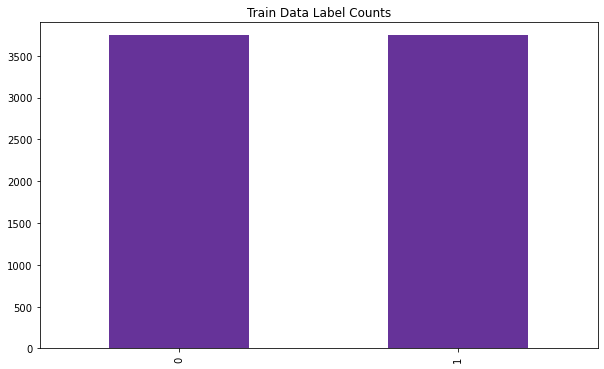

```python
print(train_labels["label"].value_counts())
fig = plt.figure()
fig.set_figheight(6)
fig.set_figwidth(10)
plt.title('Train Data Label Counts')
plt.ylim([0, 3900])
train_labels["label"].value_counts().plot.bar(color ='rebeccapurple')
plt.show()
```

```
1    1252
0    1248
Name: label, dtype: int64
```

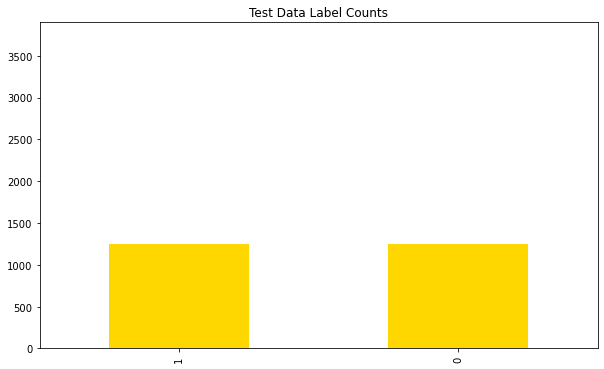

```python
print(test_labels["label"].value_counts())
fig = plt.figure()
fig.set_figheight(6)
fig.set_figwidth(10)
plt.title('Test Data Label Counts')
plt.ylim([0, 3900])
test_labels["label"].value_counts().plot.bar(color ='gold')
plt.show()
```

# Part 2: Completing the given code

# Dataloader

```python
class Dataloader:
    '''
    This class prepares the dataset for the neural network.
    '''

    def __init__(self, data, labels, n_classes, batch_size=None, shuffle=False):
        '''
        This is the constructor. It gets dataset information and initializes the
        Dataloader class fields.
            Parameters:
                data: features your dataset in pandas.Dataframe format.
                labels: labels of your dataset in pandas.Dataframe format.
                n_classes: number of classes you have in your dataset.
                batch_size: the number of samples that will be propagated through the network.
                shuffle: boolean value indicating whether or not the dataset should be shuffled
        '''

        assert len(data)==len(labels)
        self.__n_classes = n_classes
        self.__batch_size = batch_size
        self.__shuffle = shuffle
        self.__data = data
        self.__onehot_labels = self.__onehot(labels, self.__n_classes)

    def __onehot(self, labels, n_classes):
        '''
        This private method gets labels and provides one_hot vectors of labels.
        For categorical variables where no such ordinal relationship exists,
        the integer encoding is not enough.
        In this case, a one-hot encoding can be applied to the integer representation.
        This is where the integer encoded variable is removed, and a new binary variable is
        added for each unique integer value.
        example:
            red,    green,    blue
            1,      0,        0
            0,      1,        0
            0,      0,        1
                Parameters:
                        label: lables of your dataset in pandas.Dataframe format.
                        n_classes: number of classes you have in your dataset.

                Returns:
                    onehot_vectors: onehot vectors of the labels
        '''
        # TODO: Implement
        onehot_vectors = []
        for label in labels:
            if label == 0:
                onehot_vectors.append([1,0])
            elif label == 1:
                onehot_vectors.append([0,1])
        return onehot_vectors

    def __shuffle_dataset(self):
        '''
        This private method shuffles your dataset.
        It uses data and onehot_labels to shuffle them
        symmetrical.
        '''
        # TODO: Implement
        indexes = len(self.__data)
        shuffledIndex = np.random.permutation(indexes)
        self.__data, self.__onehot_labels = self.__data[shuffledIndex], self.__onehot_labels[shuffledIndex]

    def __iter__(self):
        '''
        The __iter__() function returns an iterator for the
        given object (array, set, tuple, etc., or custom objects).
        This will return your dataset in the batch_size given. This should
        be used to provide data for the neural network.
        '''

        if self.__shuffle:
            self.__shuffle_dataset()

        if self.__batch_size==None:
            yield (np.matrix(self.__data), np.matrix(self.__onehot_labels))
            return

        for idx in range(0, len(self.__data), self.__batch_size):
            yield (np.matrix(self.__data[idx:idx+self.__batch_size]),
                   np.matrix(self.__onehot_labels[idx:idx+self.__batch_size]))
```

# Activation Functions

Activation function decides, whether a neuron should be activated or not by calculating weighted sum and further adding bias with it. The purpose of the activation function is to introduce non-linearity into the output of a neuron. A neural network without an activation function is essentially just a linear regression model. An activation function in a neural network defines how the weighted sum of the input is transformed into an output from a node or nodes in a layer of the network.

In this assignment we have Identical, ReLU, LeakyReLU, Sigmoid, Softmax and Tanh activation functions.

## Identical

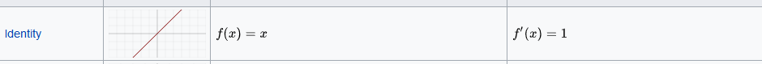

```python
class Identical:
    '''
    This is the Identical activation function. This activation function just
    return the value it gets.
    '''

    def __init__(self):
        pass
        '''
        This is the constructor. It does not have any fields
        as a result, there is no need to do anything in the constructor.
        '''

    def __val(self, matrix):
        '''
        This private method gets a matrix and uses the activity function on that.
        As this is an identical activity function, it just
        returns np.matrix of the input.

            Parameters:
                matrix: np.matrix of values
            Returns:
                identical_value: np.matrix of input with float datatypes
        '''
        identical_value = np.matrix(matrix, dtype=float)
        return identical_value

    def derivative(self, matrix):
        '''
        This method returns the derivation of the input.
        As the derivation of x is one, this method returns
        a matrix of one with the shape of the input matrix.

            Parameters:
                matrix: np.matrix of values
            Returns:
                identical_derivative: np.matrix of ones with matrix shape
        '''
        temp = np.matrix(matrix, dtype=float)
        identical_derivative = np.matrix(np.full(np.shape(temp), 1.))
        return identical_derivative

    def __call__(self, matrix):
        '''
        __call__ is a special function in Python that, when implemented inside a class,
        gives its instances (objects) the ability to behave like a function.
        Here we return the _value method output.

            Parameters:
                matrix: np.matrix of values
            Returns:
                __val(matrix): __val return value for the input matrix
        '''
        return self.__val(matrix)
```

## Relu

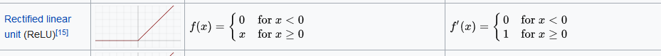

```python
class Relu:
    '''
    This is the Relu activation function.
    The rectified linear activation function or ReLU for short
    is a piecewise linear function that will output the input directly
    if it is positive, otherwise, it will output zero.
    '''

    def __init__(self):
        pass
        '''
        This is the constructor. It does not have any fields
        as a result, there is no need to do anything in the constructor.
        '''

    def __val(self, matrix):
        '''
        This private method gets a matrix and uses the activity function on that.
        It will set 0 in the matrix if the value is less than 0 else, it returns the value itself.

            Parameters:
                matrix: np.matrix of values
            Returns:
                relu_value: np.matrix of relu activation function result
        '''
        # TODO: Implement
        relu_value = np.matrix(matrix)
        relu_value = np.matrix(np.where(relu_value < 0, 0., relu_value))
        return relu_value

    def derivative(self, matrix):
        '''
        Returns the derivation value of relu function on input matrix.

            Parameters:
                matrix: np.matrix of values
            Returns:
                relu_derivative: np.matrix of relu activation function derivation result
        '''
        # TODO: Implement
        relu_derivative = np.matrix(matrix)
        relu_derivative = np.where(relu_derivative < 0, 0., 1.)
        return relu_derivative

    def __call__(self, matrix):
        '''
        __call__ is a special function in Python that, when implemented inside a class,
        gives its instances (objects) the ability to behave like a function.
        Here we return the _relu method output.

            Parameters:
                matrix: np.matrix of values
            Returns:
                __relu(matrix): __relu return value for the input matrix
        '''
        return self.__val(matrix)
```

## LeakyRelu

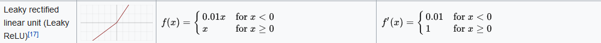

```python
class LeakyRelu:
    '''
    This is the Leaky Relu activation function.
    Leaky Rectified Linear Unit, or Leaky ReLU,
    is a type of activation function based on a ReLU,
    but it has a small slope for negative values instead
    of a flat slope.
    '''

    def __init__(self, negative_slope=0.01):
        '''
        This is the constructor.
        It sets negative_slope field.
            Parameters:
                negative_slope: slope for negative input values
        '''
        self.negative_slope = 0.01

    def __val(self, matrix):
        '''
        This private method gets a matrix and uses the activity function on that.
        It will set negative_slope*value in the matrix if the value is less than 0, else it
        returns the value itself.

            Parameters:
                matrix: np.matrix of values
            Returns:
                relu_value: np.matrix of relu activation function result
        '''
        # TODO: Implement
        leacky_relu_value = np.matrix(np.where(matrix<0, self.negative_slope*matrix, matrix))
        return leacky_relu_value

    def derivative(self, matrix):
        '''
        Returns the derivation value of leaky relu function on input matrix.

            Parameters:
                matrix: np.matrix of values
            Returns:
                leacky_relu_derivative: np.matrix of leaky relu activation function derivation result
        '''
        # TODO: Implement
        leacky_relu_derivative = np.matrix(np.where(matrix < 0, self.negative_slope, 1))
        return leacky_relu_derivative

    def __call__(self, matrix):
        '''
        __call__ is a special function in Python that, when implemented inside a class,
        gives its instances (objects) the ability to behave like a function.
        Here we return the _val method output.

            Parameters:
                matrix: np.matrix of values
            Returns:
                __val(matrix): __val return value for the input matrix
        '''
        return self.__val(matrix)
```

## Sigmoid

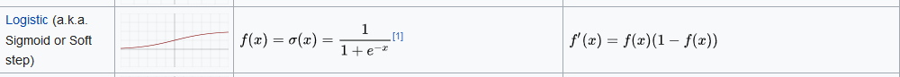

```python
class Sigmoid:
    '''
    A sigmoid function is a mathematical function having a
    characteristic "S"-shaped curve or sigmoid curve.
    It return S(x)=1/(1+e^-x)
    '''

    def __init__(self): pass

    def __val(self, matrix):
        '''
        Returns 1/(1+e^-x) of values

            Parameters:
                matrix: np.matrix of values
            Returns:
                sigmoid_value: np.matrix of relu activation function result
        '''
        # TODO: Implement
        sigmoid_value = 1/(1+np.exp(-1*matrix))
        return sigmoid_value

    def derivative(self, matrix):
        '''
        Returns the derivation value of sigmoid function on input matrix.

            Parameters:
                matrix: np.matrix of values
            Returns:
                sigmoid_derivative: np.matrix of sigmoid activation function derivation result
        '''
        # TODO: Implement
        sigmoid_value = self.__val(matrix)
        sigmoid_derivative = np.multiply(sigmoid_value, 1-sigmoid_value)
        return sigmoid_derivative

    def __call__(self, matrix):
        '''
        __call__ is a special function in Python that, when implemented inside a class,
        gives its instances (objects) the ability to behave like a function.
        Here we return the _val method output.

            Parameters:
                matrix: np.matrix of values
            Returns:
                __val(matrix): __val return value for the input matrix
        '''
        return self.__val(matrix)
```

## Softmax

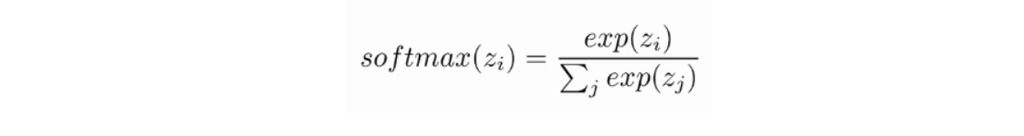

```python
class Softmax:
    '''
    The softmax function, also known as softargmax  or normalized
    exponential function is a generalization of the logistic
    function to multiple dimensions. It is used in multinomial logistic
    regression and is often used as the last activation function of a neural
    network to normalize the output of a network to a probability distribution
    over predicted output classes, based on Luce's choice axiom.
    Softmax return (e^x_i / (Σe^x_j for j = 1, ..., J))
    '''

    def __init__(self):
        pass
        '''
        This is the constructor. It does not have any fields
        as a result, there is no need to do anything in the constructor.
        '''

    def __val(self, matrix):
        '''
        This private method gets a matrix and uses the softmax on that.
        Softmax return (e^x_i / (Σe^x_j for j = 1, ..., J))

            Parameters:
                matrix: np.matrix of values
            Returns:
                relu_value: np.matrix of relu activation function result
        '''
        # TODO: Implement
        exp_val = np.exp(matrix)
        softmax_value = exp_val/exp_val.sum(axis=1)
        return softmax_value

    def __call__(self, matrix):
        '''
        __call__ is a special function in Python that, when implemented inside a class,
        gives its instances (objects) the ability to behave like a function.
        Here we return the _val method output.

            Parameters:
                matrix: np.matrix of values
            Returns:
                __val(matrix): __val return value for the input matrix
        '''
        return self.__val(matrix)
```

## Tanh

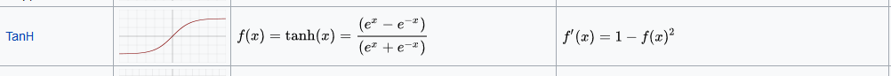

```python
class Tanh:

    def __init__(self):
        pass
#           '''
#           This is the constructor. It does not have any fields
#           as a result, there is no need to do anything in the constructor.
#           '''

    def __val(self, matrix):
        '''
        This private method gets a matrix and uses the activity function on that.
        It performs Tanh on the values.

            Parameters:
                matrix: np.matrix of values
            Returns:
                tanh_value: np.matrix of Tanh activation function result
        '''
        # TODO: Implement
        tanh_value = np.tanh(matrix)
        return tanh_value

    def derivative(self, matrix):
        '''
        Returns the derivation value of Tanh function on input matrix.

            Parameters:
                matrix: np.matrix of values
            Returns:
                sigmoid_derivative: np.matrix of Tanh activation function derivation result
        '''
        # TODO: Implement
        tanh_val = self.__val(matrix)
        tanh_derivative = 1-np.power(tanh_val, 2)
        return tanh_derivative

    def __call__(self, matrix):
        '''
        __call__ is a special function in Python that, when implemented inside a class,
        gives its instances (objects) the ability to behave like a function.
        Here we return the _val method output.

            Parameters:
                matrix: np.matrix of values
            Returns:
                __val(matrix): __val return value for the input matrix
        '''
        return self.__val(matrix)
```

# Loss Function

```python
class CrossEntropy:
    #(with softmax)
    '''
    Cross-entropy is a measure of the difference between two probability
    distributions for a given random variable or set of events. You might
    recall that information quantifies the number of bits required to encode
    and transmit an event.
    The above image can help you.
    '''

    def __init__(self):
        pass
        '''
        This is the constructor. It does not have any fields
        as a result, there is no need to do anything in the constructor.
        '''

    def __val(self, true_val, expected_val):
        '''
        L(y^, y) = - Σ (y^(k)log (y^)^(k)) for k in K
        Parameters:
            true_val: calculated values (generated by neural network)
            expected_val: real values in dataset
        Returns:
            cross_entropy_value: cross entropy of inputs
        '''

        assert np.shape(true_val)==np.shape(expected_val)
        # TODO: Implement
        sftmx = Softmax()
        # cross_entropy_value = -sum(np.multiply([expected_val[i], np.log2(sftmx(true_val)[i]) for i in range(len(true_val))])
        sftmax_true_val = sftmx(true_val)
        sftmax_true_val += 0.00000000000001
        with_mult = np.multiply(expected_val, np.log2(sftmax_true_val))
        cross_entropy_value = -(with_mult).sum(axis = 1)
        return cross_entropy_value

    def derivative(self, true_val, expected_val):
        '''
        Returns derivation of cross entropy.
            Parameters:
                true_val: calculated values (generated by neural network)
                expected_val: real values in dataset
            Returns:
                cross_entropy_derivative: cross entropy derivation of inputs
        '''
        assert np.shape(true_val)==np.shape(expected_val)
        # TODO: Implement
        sftmx = Softmax()
        true_val += 0.000000000000000001
        cross_entropy_derivative = sftmx(true_val) - expected_val
        return cross_entropy_derivative

    def __call__(self, true_val, expected_val):
        '''
        __call__ is a special function in Python that, when implemented inside a class,
        gives its instances (objects) the ability to behave like a function.
        Here we return the _val method output.

            Parameters:
                true_val: calculated values (generated by neural network)
                expected_val: real values in dataset
            Returns:
                __val(matrix): __val return value for the input matrix
        '''
        return self.__val(true_val, expected_val)
```

# Layer

**Back-propagation:** Backpropagation aims to minimize the cost function by adjusting network’s weights and biases. The level of adjustment is determined by the gradients of the cost function with respect to those parameters.gradients are computed in the direction from output to input layers and combined using chain rule.

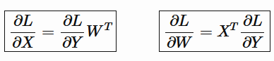

More details and proof of this can be found here: https://web.eecs.umich.edu/~justincj/teaching/eecs442/notes/linear-backprop.html

Also there is a good example of back propagation here: https://mattmazur.com/2015/03/17/a-step-by-step-backpropagation-example/

This link is helpful too: https://www.youtube.com/watch?v=aircAruvnKk

It is how I update weights by **gradient descent:**

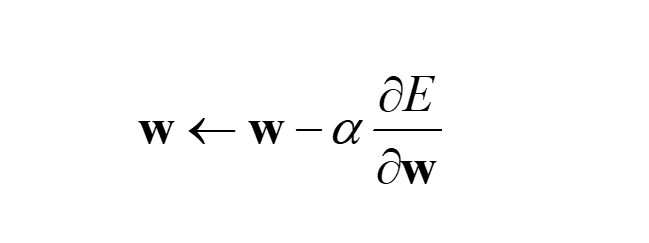

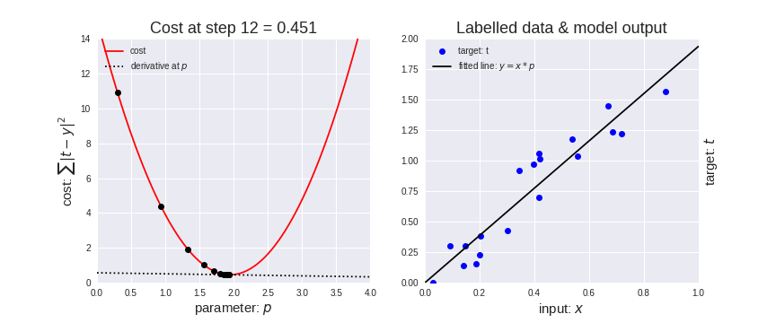

For initializing weights we use **normal** and **uniform** distributions:

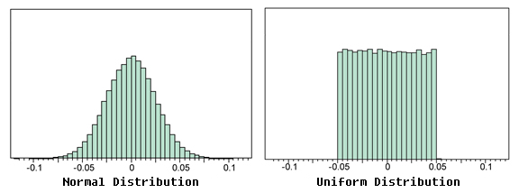

```python
class Layer:
    '''
    The layer class is used to define neural network layers.
    It stores all needed information for each layer, such as neurons count,
    weight matrix, bias, the output after applying the activation function, etc.
    '''

    DEFAULT_LOW, DEFAULT_HIGH, DEFAULT_MEAN, DEFAULT_VAR = 0, 0.05, 0., 1.

    def __init__(self, input_size, output_size, activation=Identical(), initial_weight='uniform',
                 **initializing_parameters):
        '''
        Parameters:
            input_size: the size of the input of this layer.
            output_size: the size of the output after this layer.
            activation: the activation function. It can be initialized to either of the previously defined activation classes.
                               default is an Identical activation function.
            initial_weight: either normal or uniform. It defines the method for weight initialization.
        '''

        assert type(initial_weight)==str, 'Undefined activation function!'

        self.__weight_initializer_dict = {'uniform':self.__uniform_weight, 'normal':self.__normal_weight}

        assert initial_weight in self.__weight_initializer_dict, 'Undefined weight initialization function!'


        self.__n_neurons = output_size
        weight_initializer = self.__weight_initializer_dict[initial_weight]
        self.__weight = weight_initializer(input_size, self.__n_neurons, **initializing_parameters)
        self.__bias = weight_initializer(1, self.__n_neurons, **initializing_parameters)
        self.__activation = activation

        self.__last_input = None
        self.__last_activation_input = None
        self.__last_activation_output = None
        self.__last_activation_derivative = None

    def forward(self, layer_input):
        '''
        It calculates the output of this layer for the layer_input argument.
        This method also stores __last_input, __last_activation_input, and __last_activation_derivative
        for future use in backpropagation.
        Parameters:
            layer_input: 2d np.matrix representing the input matrix of this layer.
        Returns:
            Final output of this layer after applying the activation function.
        '''
        assert np.ndim(layer_input)==2
        assert np.size(self.__weight,0) == np.size(layer_input,1)
        # TODO: Implement

        self.__last_input = layer_input
        self.__last_activation_input = (layer_input*self.__weight)+self.__bias
        self.__last_activation_output = self.__activation(self.__last_activation_input)
        self.__last_activation_derivative = self.__activation.derivative(self.__last_activation_input)
        return self.__last_activation_output

    def update_weights(self, backprop_tensor, lr):
        '''
        It updates Layer weights according to the backpropagation matrix and learning rate.
        This method updates bias values as well.
        Parameters:
            backprop_tensor: 2d np.matrix passed from the next layer containing gradient values.
            lr: learning rate
        Returns:
            backprop_tensor to be used by the previous layer.
        '''
        assert np.ndim(backprop_tensor)==2
        assert np.size(backprop_tensor,0) == np.size(self.__last_activation_derivative,0)
        assert np.size(backprop_tensor,1) == self.__n_neurons
        # TODO: Implement
        # print("weight: ", self.__weight.shape)
        # print("back:", backprop_tensor.shape)
        dE_by_dNet = np.multiply(backprop_tensor, self.__last_activation_derivative)
        backprop_tensor = np.dot(dE_by_dNet, self.__weight.T)
        dE_by_dw = np.dot(self.__last_input.T, dE_by_dNet)
        self.__weight -= (lr*dE_by_dw)
        dE_by_db = np.dot(np.ones((dE_by_dNet.shape[0])), dE_by_dNet)
        self.__bias -= (lr*dE_by_db)

        return backprop_tensor

    def __uniform_weight(self, dim1, dim2, **initializing_parameters):
        '''
        Initializes weights as a uniform distribution between low and high values.
        It uses default low and high values unless low or high are passed in initializing_parameters.
        Parameters:
            dim1: the size of the first dimension of weights.
            dim2: the size of the second dimension of weights.
            initializing_parameters: other initializing parameters; it can include custom low or high values.
        Returns:
            np.matrix with size (dim1, dim2) initialized using uniformly distributed values.
        '''
        low, high = self.DEFAULT_LOW, self.DEFAULT_HIGH
        if 'low' in initializing_parameters.keys(): low = initializing_parameters['low']
        if 'high' in initializing_parameters.keys(): high = initializing_parameters['high']
        # TODO: Implement
        weights = np.random.uniform(low, high, size = (dim1, dim2))
        return weights

    def __normal_weight(self, dim1, dim2, **initializing_parameters):
        '''
        Initializes weights as a normal distribution with mean and var values.
        It uses default mean and variance values unless mean or var are passed in initializing_parameters.
        Parameters:
            dim1: the size of the first dimension of weights.
            dim2: the size of the second dimension of weights.
            initializing_parameters: other initializing parameters; it can include custom mean or var values.
        Returns:
            np.matrix with size (dim1, dim2) initialized using normaly distributed values.
        '''
        mean, var = self.DEFAULT_MEAN, self.DEFAULT_VAR
        if 'mean' in initializing_parameters.keys(): mean = initializing_parameters['mean']
        if 'var' in initializing_parameters.keys(): var = initializing_parameters['var']
        # TODO: Implement
        weights = np.random.normal(mean, var, size=(dim1, dim2))
        return weights

    @property
    def n_neurons(self): return self.__n_neurons

    @property
    def weight(self): return self.__weight

    @property
    def bias(self): return self.__bias

    @property
    def activation(self): return self.__activation
```

# Feed Forward Neural Network

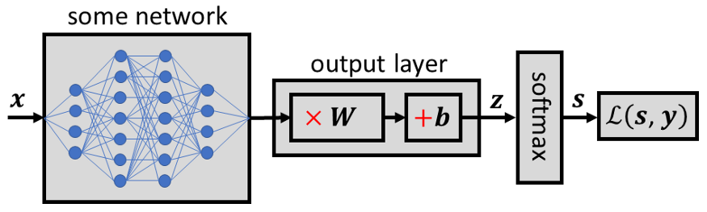

```python
class FeedForwardNN:
    '''
    This class is used in order to implement custom feed-forward neural networks.
    The FeedForwardNN class stores a list of layers that determines all network layers.
    It also consists of the learning rate and loss function.
    '''
    def __init__(self, input_shape):
        '''
        Parameters:
            input_shape: the size of the first input to our neural network.
        '''

        self.__input_shape = input_shape
        self.__output_shape = None

        self.__layers_list = []

        self.__lr = None
        self.__loss = None


    def add_layer(self, n_neurons, activation=Relu(), initial_weight='uniform', **initializing_parameters):
        '''
         This method adds a new custom layer to the layers_list.
         Parameters:
             n_neurons: number of neurons in this layer
             activation: the activation function of this layer, default is Relu
             initial_weight: either a uniform or normal, default is uniform
             initializing_parameters: other initializing parameters such as low, high, mean, var, etc
        '''

        assert type(n_neurons)==int, "Invalid number of neurons for the layer!"
        assert n_neurons>0, "Invalid number of neurons for the layer!"

        n_prev_neurons = self.__input_shape if len(self.__layers_list)==0 else self.__layers_list[-1].n_neurons
        new_layer = Layer(n_prev_neurons, n_neurons, activation, initial_weight, **initializing_parameters)
        self.__layers_list.append(new_layer)
        self.__output_shape = self.__layers_list[-1].n_neurons


    def set_training_param(self, loss=CrossEntropy(), lr=1e-3):
        '''
        This method is used to set training parameters.
        Parameters:
            loss: loss function, default is CrossEntropy
            lr: learning rate, default is 1e-3
        '''
        assert self.__layers_list, "Uncomplete model!"
        self.__loss = loss
        self.__lr = lr


    def forward(self, network_input):
        '''
        This method calculates the output of the complete neural network for a passed input.
        Parameters:
            network_input: input of the neural network
        Returns:
            network_output: output of the neural network after forwarding the network_input
        '''
        assert type(self.__output_shape) != None, "Model is not compiled!"
        # TODO: Implement
        all_layers = self.__layers_list
        next_layer_input = network_input
        for layer in all_layers:
            next_layer_input = layer.forward(next_layer_input)

        network_output = next_layer_input
        return network_output


    def fit(self, epochs, trainloader, testloader=None, print_results=True):
        '''
        This method trains the neural network using specified parameters.
        It runs the __train private method epoch times and fills the log dictionary.
        Parameters:
            epochs: number of epochs to run
            trainloader: DataLoader for train data
            testloader: DataLoader for test data
            print_results: whether or not to print the results
        Returns:
            log: complete log of the training process as a dictionary consisting of
            train_accuracy, train_loss, test_accuracy, test_loss
        '''

        assert type(self.__output_shape) != None, "Model is not compiled!"
        assert type(self.__lr) != None and type(self.__loss) != None, "Training paramenters are not set!"

        log = {"train_accuracy":[], "train_loss":[], "test_accuracy":[], "test_loss":[]}

        for epoch in range(1, epochs+1):

            if print_results:
                print('Epoch {}:'.format(epoch))

            average_accuracy, average_loss = self.__train(trainloader)
            log['train_accuracy'].append(average_accuracy)
            log['train_loss'].append(average_loss)
            if print_results:
                print('\tTrain: Average Accuracy: {}\tAverage Loss: {}'.format(average_accuracy, average_loss))

            if type(testloader) != type(None):
                average_accuracy, average_loss = self.__test(testloader)
                log['test_accuracy'].append(average_accuracy)
                log['test_loss'].append(average_loss)
                if print_results:
                    print('\tTest: Average Accuracy: {}\tAverage Loss: {}'.format(average_accuracy, average_loss))

        return log


    def __train(self, trainloader):
        '''
        Trains the neural network for one epoch.
        Parameters:
            trainloader: A DataLoader consisting of train data
        Returns:
            batch_accuracy, batch_loss: mean of all batch_accuracies, batch_losses
        '''
        bach_accuracies, batch_losses = [], []
        for x_train, y_train in trainloader:
            batch_accuracy, batch_loss = self.__train_on_batch(x_train, y_train)
            bach_accuracies.append(batch_accuracy)
            batch_losses.append(batch_loss)
        return np.mean(bach_accuracies), np.mean(batch_losses)


    def __test(self, testloader):
        '''
        Test the neural network using a testloader.
        Parameters:
            testloader: A DataLoader of test data
        Returns:
            batch_accuracy, batch_loss: mean of all batch_accuracies, batch_losses
        '''
        bach_accuracies, batch_losses = [], []
        for x_test, y_test in testloader:
            batch_accuracy, batch_loss = self.__test_on_batch(x_test, y_test)
            bach_accuracies.append(batch_accuracy)
            batch_losses.append(batch_loss)
        return np.mean(bach_accuracies), np.mean(batch_losses)


    def __get_labels(self, outputs):
        '''
        Parameters:
            outputs: output of the neural network
        Returns:
            labels: labels generated from the outputs of the neural network
        '''
        # TODO: Implement
        label = []
        for output in outputs:
            if output[0,0] > output[0,1]:
                label.append([1,0])
            else:
                label.append([0,1])
        label = np.matrix(label)
        return label


    def __compute_accuracy(self, output, expected_output):
        '''
        Computes accuracy by comparing output and expected_output.
        Parameters:
            output: actual output of the neural network
            expected_output: expected output
        Returns:
            accuracy
        '''
        # TODO: Implement

        # print("output:")
        # print(output)
        # print("one hot:")
        # print(onehot_output_vectors)
        eval_output = np.all(self.__get_labels(output) == expected_output, axis=1)
        accuracy = eval_output.sum()/len(expected_output)
        return accuracy


    def __update_weights(self, output, y_train):
        '''
        Updates weights of all layers according to neural network output and labels.
        Parameters:
            output: output of the neural network
            y_train: y labels for one batch of train data
        Returns:
            None
        '''
        # TODO: Implement
        loss_function = self.__loss
        learning_rate = self.__lr
        backprop = loss_function.derivative(output, y_train)
        for i in range(len(self.__layers_list)-1, -1, -1):
            # print("layer: ", i)
            backprop = self.__layers_list[i].update_weights(backprop, learning_rate)
        return


    def __train_on_batch(self, x_batch, y_batch):
        '''
        Trains the neural network for one batch of train data.
        Parameters:
            x_batch: one batch data
            y_batch: labels for one batch
        Returns:
            (batch_accuracy, batch_average_loss)
        '''
        # TODO: Implement
        feed_forward_data = self.forward(x_batch)
        batch_average_loss = np.mean(self.__loss(feed_forward_data, y_batch))
        batch_accuracy = self.__compute_accuracy(feed_forward_data, y_batch)
        self.__update_weights(feed_forward_data, y_batch)
        return (batch_accuracy, batch_average_loss)


    def __test_on_batch(self, x_batch, y_batch):
        '''
        Tests the neural network for one batch of test data.
        Parameters:
            x_batch: one batch data
            y_batch: labels for one batch
        Returns:
            (batch_accuracy, batch_average_loss)
        '''
        # TODO: Implement
        feed_forward_data = self.forward(x_batch)
        batch_accuracy = self.__compute_accuracy(feed_forward_data, y_batch)
        batch_average_loss = np.mean(self.__loss(feed_forward_data, y_batch))
        return (batch_accuracy, batch_average_loss)
```

# Part 3: Data Classification

### 1) Train Data

```python
# Sample code for building and training a model

INPUT_SHAPE = 1024
LEARNING_RATE = 0.001
EPOCHS = 25
batch_size = 32
n_classes = 2
TRAINLOADER = Dataloader(train_data.to_numpy(), train_labels.to_numpy(), n_classes, batch_size=32, shuffle=False)
TESTLOADER = Dataloader(test_data.to_numpy(), test_labels.to_numpy(), n_classes, batch_size=32, shuffle=False)


network = FeedForwardNN(INPUT_SHAPE)
network.add_layer(16, input_shape=INPUT_SHAPE, activation=Relu(), weight_initializer='uniform')
network.add_layer(2, activation=Identical(), weight_initializer='uniform')
network.set_training_param(loss=CrossEntropy(), lr=LEARNING_RATE)

log = network.fit(EPOCHS, TRAINLOADER, TESTLOADER)
```

```
Epoch 1:
	Train: Average Accuracy: 0.5121010638297873	Average Loss: 1.7614778814688088
	Test: Average Accuracy: 0.5751582278481012	Average Loss: 0.984352680424907
Epoch 2:
	Train: Average Accuracy: 0.5949468085106383	Average Loss: 0.9630908731548374
	Test: Average Accuracy: 0.6269778481012658	Average Loss: 0.9445621404918416
Epoch 3:
	Train: Average Accuracy: 0.6238031914893617	Average Loss: 0.930782953828289
	Test: Average Accuracy: 0.6412183544303798	Average Loss: 0.9204487263558963
Epoch 4:
	Train: Average Accuracy: 0.6343085106382979	Average Loss: 0.9080291844586618
	Test: Average Accuracy: 0.6424050632911392	Average Loss: 0.906478476259975
Epoch 5:
	Train: Average Accuracy: 0.647517730496454	Average Loss: 0.887584101039552
	Test: Average Accuracy: 0.6574367088607594	Average Loss: 0.8775137805460905
Epoch 6:
	Train: Average Accuracy: 0.6611258865248226	Average Loss: 0.8686739971667465
	Test: Average Accuracy: 0.6744462025316456	Average Loss: 0.8621144890622404
Epoch 7:
	Train: Average Accuracy: 0.678014184397163	Average Loss: 0.8516822711928681
	Test: Average Accuracy: 0.7001582278481012	Average Loss: 0.8421062410224387
Epoch 8:
	Train: Average Accuracy: 0.6907358156028369	Average Loss: 0.8340255043559908
	Test: Average Accuracy: 0.7068829113924051	Average Loss: 0.8271487478753994
Epoch 9:
	Train: Average Accuracy: 0.6997783687943263	Average Loss: 0.8154729379534051
	Test: Average Accuracy: 0.7262658227848101	Average Loss: 0.8062005468121154
Epoch 10:
	Train: Average Accuracy: 0.711613475177305	Average Loss: 0.7989722852858118
	Test: Average Accuracy: 0.7290348101265823	Average Loss: 0.7885009399364347
Epoch 11:
	Train: Average Accuracy: 0.7175975177304965	Average Loss: 0.7854634512434358
	Test: Average Accuracy: 0.7314082278481012	Average Loss: 0.7816739267618925
Epoch 12:
	Train: Average Accuracy: 0.7255762411347518	Average Loss: 0.7722702740678863
	Test: Average Accuracy: 0.7274525316455697	Average Loss: 0.7750224081713715
Epoch 13:
	Train: Average Accuracy: 0.7315602836879433	Average Loss: 0.7642782176006768
	Test: Average Accuracy: 0.7389240506329114	Average Loss: 0.7699610617288158
Epoch 14:
```

[output cut: 20 more lines]

```
Epoch 21:
	Train: Average Accuracy: 0.7535017730496455	Average Loss: 0.7118831433335066
	Test: Average Accuracy: 0.7444620253164557	Average Loss: 0.7588641572723568
Epoch 22:
	Train: Average Accuracy: 0.7585549645390072	Average Loss: 0.7053078885205863
	Test: Average Accuracy: 0.7468354430379747	Average Loss: 0.7627217861128335
Epoch 23:
	Train: Average Accuracy: 0.7593528368794327	Average Loss: 0.7009808393438383
	Test: Average Accuracy: 0.745253164556962	Average Loss: 0.7606133141914316
Epoch 24:
	Train: Average Accuracy: 0.7615248226950354	Average Loss: 0.6955603446300778
	Test: Average Accuracy: 0.7420886075949367	Average Loss: 0.7667869263633076
Epoch 25:
	Train: Average Accuracy: 0.7619237588652481	Average Loss: 0.6916966298288567
	Test: Average Accuracy: 0.7377373417721519	Average Loss: 0.7672559221998273
```

### 2) Weights

**Question: what if we initialize all weights to zero?** Initializing all the weights with zeros leads the neurons to learn the same features during training. By initializing to zero all hidden units will have **identical influence** on the cost, which will lead to identical gradients. Thus, both neurons will evolve symmetrically throughout training, effectively preventing different neurons from learning different things. Also, this will lead us neural network to get in **local minima**, and all the neurons will follow the same gradient, and will always end up doing the same thing as one another. If all the weights are initialized to zeros, the derivatives will remain same for every weight. As a result, neurons will learn same features in each iterations. This problem is known as network failing to break **symmetry**. And not only zero, any **constant initialization** will produce a poor result. So it causes the neuron to memorize the the same functions almost in each iteration.

### 3) Effect of Learning Rate

The learning rate is a hyperparameter that controls how much to **change** the model in response to the estimated error each time the model weights are updated. Choosing the learning rate is challenging as a value too **small** may result in a **long training process** that could get stuck, whereas a value too **large** may result in learning a sub-optimal set of weights too fast or an **unstable** training process.

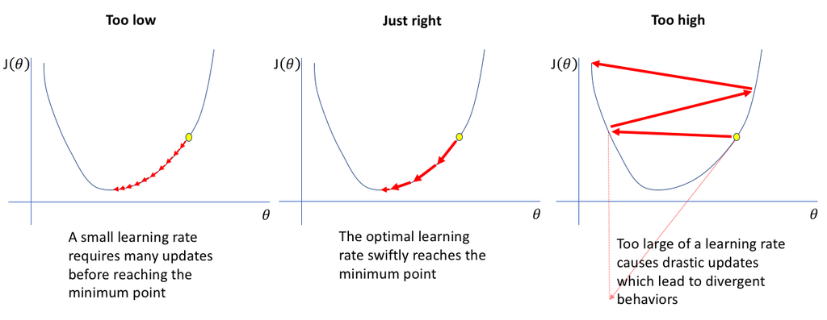

```python
lrs = [0.0001, 0.001, 0.005, 0.01]
train_accuracies = []
test_accuracies = []
for lr in lrs:
    print(f"-------------------learning rate: {lr}----------------------")
    INPUT_SHAPE = 1024
    LEARNING_RATE = lr
    EPOCHS = 25
    batch_size = 32
    n_classes = 2
    TRAINLOADER = Dataloader(train_data.to_numpy(), train_labels.to_numpy(), n_classes, batch_size=32, shuffle=False)
    TESTLOADER = Dataloader(test_data.to_numpy(), test_labels.to_numpy(), n_classes, batch_size=32, shuffle=False)

    network = FeedForwardNN(INPUT_SHAPE)
    network.add_layer(16, input_shape=INPUT_SHAPE, activation=Relu(), weight_initializer='uniform')
    network.add_layer(2, activation=Identical(), weight_initializer='uniform')
    network.set_training_param(loss=CrossEntropy(), lr=LEARNING_RATE)

    log = network.fit(EPOCHS, TRAINLOADER, TESTLOADER)
    train_accuracies.append(log['train_accuracy'][-1])
    test_accuracies.append(log['test_accuracy'][-1])

print(f"train accuracies: {train_accuracies}")
print(f"test accuracies: {test_accuracies}")
best_train_lr = lrs[train_accuracies.index(max(train_accuracies))]
best_test_lr = lrs[test_accuracies.index(max(test_accuracies))]
print(f"best train accuracy: {best_train_lr}")
print(f"best test accuracy: {best_test_lr}")
```

```
-------------------learning rate: 0.0001----------------------
Epoch 1:
	Train: Average Accuracy: 0.5077127659574469	Average Loss: 2.065242276790745
	Test: Average Accuracy: 0.4988132911392405	Average Loss: 0.9988752016931098
Epoch 2:
	Train: Average Accuracy: 0.5063829787234042	Average Loss: 1.6853000309349102
	Test: Average Accuracy: 0.504746835443038	Average Loss: 0.9993176864905075
Epoch 3:
	Train: Average Accuracy: 0.504122340425532	Average Loss: 1.4451473509580306
	Test: Average Accuracy: 0.504746835443038	Average Loss: 0.9992631970729563
Epoch 4:
	Train: Average Accuracy: 0.5091755319148936	Average Loss: 1.312486011676868
	Test: Average Accuracy: 0.5079113924050633	Average Loss: 0.9931694108332068
Epoch 5:
	Train: Average Accuracy: 0.5107712765957447	Average Loss: 1.2217299519063132
	Test: Average Accuracy: 0.5193829113924051	Average Loss: 0.9897566577272939
Epoch 6:
	Train: Average Accuracy: 0.5160904255319149	Average Loss: 1.1733381414982484
	Test: Average Accuracy: 0.5296677215189873	Average Loss: 0.986954145854858
Epoch 7:
	Train: Average Accuracy: 0.5211436170212767	Average Loss: 1.1339421779467387
	Test: Average Accuracy: 0.5510284810126582	Average Loss: 0.9813178247012
Epoch 8:
	Train: Average Accuracy: 0.5289450354609929	Average Loss: 1.1019759258876662
	Test: Average Accuracy: 0.5727848101265823	Average Loss: 0.9749265788336038
Epoch 9:
	Train: Average Accuracy: 0.5392730496453901	Average Loss: 1.0767536382645468
	Test: Average Accuracy: 0.5846518987341772	Average Loss: 0.96911061484679
Epoch 10:
	Train: Average Accuracy: 0.547517730496454	Average Loss: 1.0570025751486232
	Test: Average Accuracy: 0.5933544303797469	Average Loss: 0.9640745379274948
Epoch 11:
	Train: Average Accuracy: 0.5549645390070923	Average Loss: 1.041256687964342
	Test: Average Accuracy: 0.6075949367088608	Average Loss: 0.9596138396672067
Epoch 12:
	Train: Average Accuracy: 0.5625	Average Loss: 1.0282732904797318
	Test: Average Accuracy: 0.6131329113924051	Average Loss: 0.9555327073539109
Epoch 13:
	Train: Average Accuracy: 0.5674202127659574	Average Loss: 1.017181477153876
	Test: Average Accuracy: 0.6159018987341772	Average Loss: 0.9517468803962212
```

[output cut: 253 more lines]

```
	Train: Average Accuracy: 0.49840425531914895	Average Loss: 1.0026515643961558
	Test: Average Accuracy: 0.495253164556962	Average Loss: 1.000649532831052
Epoch 23:
	Train: Average Accuracy: 0.49840425531914895	Average Loss: 1.0026515643961558
	Test: Average Accuracy: 0.495253164556962	Average Loss: 1.000649532831052
Epoch 24:
	Train: Average Accuracy: 0.49840425531914895	Average Loss: 1.0026515643961558
	Test: Average Accuracy: 0.495253164556962	Average Loss: 1.000649532831052
Epoch 25:
	Train: Average Accuracy: 0.49840425531914895	Average Loss: 1.0026515643961558
	Test: Average Accuracy: 0.495253164556962	Average Loss: 1.000649532831052
train accuracies: [0.6193705673758865, 0.7660017730496455, 0.49813829787234043, 0.49840425531914895]
test accuracies: [0.6420094936708861, 0.7385284810126582, 0.495253164556962, 0.495253164556962]
best train accuracy: 0.001
best test accuracy: 0.001
```

Best learning rate is 0.001

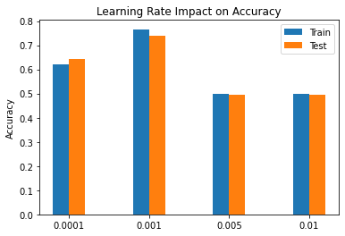

```python
labels = ["0.0001", "0.001", "0.005", "0.01"]
y_pos = np.arange(len(labels))
width = 0.2
plt.bar(y_pos - width/2, train_accuracies, width, label='Train')
plt.bar(y_pos + width/2, test_accuracies, width, label='Test')
plt.xticks(y_pos, labels)
plt.ylabel('Accuracy')
plt.title('Learning Rate Impact on Accuracy')
plt.legend()
fig.tight_layout()
plt.show()
```

### Learning Rate x 0.1 & Learning Rate x 10

```python
lr_multiplicant = [0.1, 10]
train_accuracies = []
test_accuracies = []
for mult in lr_multiplicant:
    print(f"-------------------learning rate * {mult}----------------------")
    INPUT_SHAPE = 1024
    LEARNING_RATE = best_test_lr * mult
    EPOCHS = 25
    batch_size = 32
    n_classes = 2
    TRAINLOADER = Dataloader(train_data.to_numpy(), train_labels.to_numpy(), n_classes, batch_size, shuffle=False)
    TESTLOADER = Dataloader(test_data.to_numpy(), test_labels.to_numpy(), n_classes, batch_size, shuffle=False)

    network = FeedForwardNN(INPUT_SHAPE)
    network.add_layer(16, input_shape=INPUT_SHAPE, activation=Relu(), weight_initializer='uniform')
    network.add_layer(2, activation=Identical(), weight_initializer='uniform')
    network.set_training_param(loss=CrossEntropy(), lr=LEARNING_RATE)

    log = network.fit(EPOCHS, TRAINLOADER, TESTLOADER)
```

```
-------------------learning rate * 0.1----------------------
Epoch 1:
	Train: Average Accuracy: 0.5071808510638298	Average Loss: 2.1103825653738357
	Test: Average Accuracy: 0.504746835443038	Average Loss: 0.9985592157798847
Epoch 2:
	Train: Average Accuracy: 0.5089095744680852	Average Loss: 1.703469954207226
	Test: Average Accuracy: 0.504746835443038	Average Loss: 0.9995408041007596
Epoch 3:
	Train: Average Accuracy: 0.5043882978723404	Average Loss: 1.4635792558159675
	Test: Average Accuracy: 0.504746835443038	Average Loss: 0.9999721034604766
Epoch 4:
	Train: Average Accuracy: 0.5058510638297873	Average Loss: 1.322283256930148
	Test: Average Accuracy: 0.5039556962025317	Average Loss: 0.9951818806037325
Epoch 5:
	Train: Average Accuracy: 0.5075797872340425	Average Loss: 1.2272722507821856
	Test: Average Accuracy: 0.5122626582278481	Average Loss: 0.9916021669203395
Epoch 6:
	Train: Average Accuracy: 0.5111702127659574	Average Loss: 1.1782913645589481
	Test: Average Accuracy: 0.5150316455696202	Average Loss: 0.9894318169425638
Epoch 7:
	Train: Average Accuracy: 0.5184840425531915	Average Loss: 1.13882907685563
	Test: Average Accuracy: 0.5379746835443038	Average Loss: 0.9839132078284879
Epoch 8:
	Train: Average Accuracy: 0.5244237588652482	Average Loss: 1.1064331150374154
	Test: Average Accuracy: 0.5688291139240507	Average Loss: 0.9771012092327654
Epoch 9:
	Train: Average Accuracy: 0.5381205673758865	Average Loss: 1.080467119369203
	Test: Average Accuracy: 0.5799050632911392	Average Loss: 0.9706689257424757
Epoch 10:
	Train: Average Accuracy: 0.545700354609929	Average Loss: 1.059934781385796
	Test: Average Accuracy: 0.5957278481012658	Average Loss: 0.9651008492443894
Epoch 11:
	Train: Average Accuracy: 0.5520833333333333	Average Loss: 1.0435837229908598
	Test: Average Accuracy: 0.6091772151898734	Average Loss: 0.9602667861179177
Epoch 12:
	Train: Average Accuracy: 0.5606382978723404	Average Loss: 1.030203407026924
	Test: Average Accuracy: 0.6190664556962026	Average Loss: 0.9559214596460751
Epoch 13:
	Train: Average Accuracy: 0.5678191489361702	Average Loss: 1.0188577845421236
	Test: Average Accuracy: 0.6194620253164557	Average Loss: 0.9519171776352838
```

[output cut: 97 more lines]

```
Epoch 21:
	Train: Average Accuracy: 0.49840425531914895	Average Loss: 1.0026515643961558
	Test: Average Accuracy: 0.495253164556962	Average Loss: 1.000649532831052
Epoch 22:
	Train: Average Accuracy: 0.49840425531914895	Average Loss: 1.0026515643961558
	Test: Average Accuracy: 0.495253164556962	Average Loss: 1.000649532831052
Epoch 23:
	Train: Average Accuracy: 0.49840425531914895	Average Loss: 1.0026515643961558
	Test: Average Accuracy: 0.495253164556962	Average Loss: 1.000649532831052
Epoch 24:
	Train: Average Accuracy: 0.49840425531914895	Average Loss: 1.0026515643961558
	Test: Average Accuracy: 0.495253164556962	Average Loss: 1.000649532831052
Epoch 25:
	Train: Average Accuracy: 0.49840425531914895	Average Loss: 1.0026515643961558
	Test: Average Accuracy: 0.495253164556962	Average Loss: 1.000649532831052
```

The small learning rate made the training slower and did not get a satisfying result. Large learning rate did not get good accuracies either. a large learning rate allows the model to learn faster, at the cost of arriving on a sub-optimal final set of weights.

### 4) Effect of Activation Function

```python
activation_functions = [Relu(), Sigmoid(), Tanh(), LeakyRelu()]
activation_string = ["Relu", "Sigmoid", "Tanh", "LeakyRelu"]
train_accuracies = []
test_accuracies = []
for i in range(len(activation_functions)):
    print(f"-------------------activation function: {activation_string[i]}----------------------")
    INPUT_SHAPE = 1024
    LEARNING_RATE = best_test_lr
    EPOCHS = 25
    batch_size = 32
    n_classes = 2
    TRAINLOADER = Dataloader(train_data.to_numpy(), train_labels.to_numpy(), n_classes, batch_size, shuffle=False)
    TESTLOADER = Dataloader(test_data.to_numpy(), test_labels.to_numpy(), n_classes, batch_size, shuffle=False)

    network = FeedForwardNN(INPUT_SHAPE)
    network.add_layer(16, input_shape=INPUT_SHAPE, activation=activation_functions[i], weight_initializer='uniform')
    network.add_layer(2, activation=Identical(), weight_initializer='uniform')
    network.set_training_param(loss=CrossEntropy(), lr=LEARNING_RATE)

    log = network.fit(EPOCHS, TRAINLOADER, TESTLOADER)
    train_accuracies.append(log['train_accuracy'][-1])
    test_accuracies.append(log['test_accuracy'][-1])

print(f"train accuracies: {train_accuracies}")
print(f"test accuracies: {test_accuracies}")
best_train_activation = activation_functions[train_accuracies.index(max(train_accuracies))]
best_test_activation = activation_functions[test_accuracies.index(max(test_accuracies))]
print(f"best train accuracy: {activation_string[train_accuracies.index(max(train_accuracies))]}")
print(f"best test accuracy: {activation_string[test_accuracies.index(max(test_accuracies))]}")
```

```
-------------------activation function: Relu----------------------
Epoch 1:
	Train: Average Accuracy: 0.5107712765957447	Average Loss: 1.7775243291323686
	Test: Average Accuracy: 0.5747626582278481	Average Loss: 0.984441591238559
Epoch 2:
	Train: Average Accuracy: 0.5922872340425532	Average Loss: 0.9666448597447536
	Test: Average Accuracy: 0.620253164556962	Average Loss: 0.9499806009912646
Epoch 3:
	Train: Average Accuracy: 0.6268617021276596	Average Loss: 0.9378000062090042
	Test: Average Accuracy: 0.6364715189873418	Average Loss: 0.9258393430941718
Epoch 4:
	Train: Average Accuracy: 0.6378102836879433	Average Loss: 0.914602505695657
	Test: Average Accuracy: 0.6435917721518988	Average Loss: 0.9098400441385592
Epoch 5:
	Train: Average Accuracy: 0.6503989361702127	Average Loss: 0.8918460693136768
	Test: Average Accuracy: 0.6653481012658228	Average Loss: 0.8771345872182407
Epoch 6:
	Train: Average Accuracy: 0.6683953900709221	Average Loss: 0.8658391662346961
	Test: Average Accuracy: 0.7005537974683544	Average Loss: 0.843101648135813
Epoch 7:
	Train: Average Accuracy: 0.6894060283687944	Average Loss: 0.8403677207564088
	Test: Average Accuracy: 0.7143987341772152	Average Loss: 0.8176331829386763
Epoch 8:
	Train: Average Accuracy: 0.7003546099290779	Average Loss: 0.8178310234764234
	Test: Average Accuracy: 0.7223101265822784	Average Loss: 0.7981411489215132
Epoch 9:
	Train: Average Accuracy: 0.7117907801418439	Average Loss: 0.801807154252815
	Test: Average Accuracy: 0.723496835443038	Average Loss: 0.7909448766956723
Epoch 10:
	Train: Average Accuracy: 0.7159131205673758	Average Loss: 0.7899309910984038
	Test: Average Accuracy: 0.7227056962025317	Average Loss: 0.7827512611273725
Epoch 11:
	Train: Average Accuracy: 0.7208333333333332	Average Loss: 0.7792390904684929
	Test: Average Accuracy: 0.7254746835443038	Average Loss: 0.7730406833546517
Epoch 12:
	Train: Average Accuracy: 0.725886524822695	Average Loss: 0.7703580681657418
	Test: Average Accuracy: 0.7231012658227848	Average Loss: 0.775858996554946
Epoch 13:
	Train: Average Accuracy: 0.7299645390070922	Average Loss: 0.7646451570843863
	Test: Average Accuracy: 0.7278481012658228	Average Loss: 0.7741176763027249
```

[output cut: 253 more lines]

```
	Train: Average Accuracy: 0.7610372340425532	Average Loss: 0.7017020039811834
	Test: Average Accuracy: 0.7464398734177216	Average Loss: 0.7460428274183543
Epoch 23:
	Train: Average Accuracy: 0.7645390070921987	Average Loss: 0.6956849058194567
	Test: Average Accuracy: 0.7460443037974683	Average Loss: 0.745993608547286
Epoch 24:
	Train: Average Accuracy: 0.7659574468085106	Average Loss: 0.6916877266658883
	Test: Average Accuracy: 0.7444620253164557	Average Loss: 0.7481202391033506
Epoch 25:
	Train: Average Accuracy: 0.7708776595744681	Average Loss: 0.6865372743486227
	Test: Average Accuracy: 0.747626582278481	Average Loss: 0.7480982927862616
train accuracies: [0.7648049645390071, 0.49281914893617024, 0.49281914893617024, 0.7708776595744681]
test accuracies: [0.7397151898734177, 0.495253164556962, 0.495253164556962, 0.747626582278481]
best train accuracy: LeakyRelu
best test accuracy: LeakyRelu
```

In my results, the **ReLU** and **leaky ReLU** activation functions gets almost same accuracy. They are both drastically better than Sigmoid and Tanh activation functions.

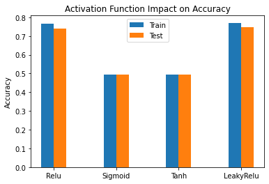

```python
labels = ["Relu", "Sigmoid", "Tanh", "LeakyRelu"]
y_pos = np.arange(len(labels))
width = 0.2
plt.bar(y_pos - width/2, train_accuracies, width, label='Train')
plt.bar(y_pos + width/2, test_accuracies, width, label='Test')
plt.xticks(y_pos, labels)
plt.ylabel('Accuracy')
plt.title('Activation Function Impact on Accuracy')
plt.legend()
fig.tight_layout()
plt.show()
```

**Question: what is the problem of Sigmoid and Tanh activation functions?**

They suffer from **saturation** problem. A neuron is considered as saturated if it reaches its **maximum or minimum value**, so that its derivative will be 0. In that case, there is no update in weights. The **gradient** of the loss function with respect to weights consequently **vanishes** till it goes down to **zero**. This is known as **vanishing gradient** that causes poor learning for deep networks. Vanishing gradients make it difficult to know which direction the parameters should move to improve the cost function

**Sigmoid:**

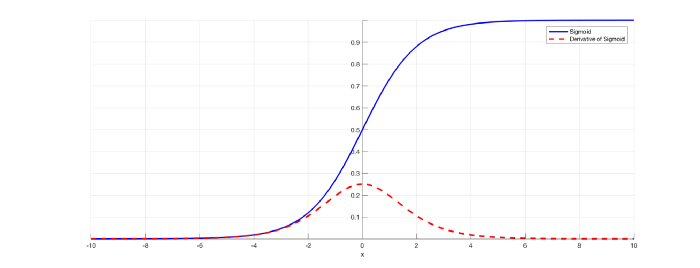

**Tanh:**

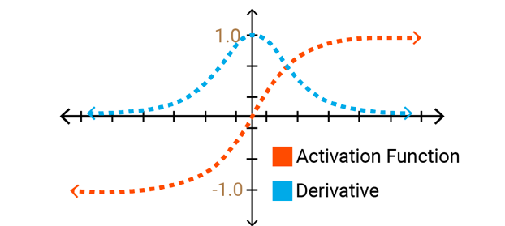

**Question: Leaky ReLU vs ReLU?** Leaky ReLU has a small slope for negative values, instead of altogether zero. The downside for being zero for all negative values is a problem called **dying ReLU**. A ReLU neuron is **dead** if it’s stuck in the negative side and always outputs 0. Because the slope of ReLU in the negative range is also 0, once a neuron gets negative, it’s unlikely for it to recover. Actually this dead neurons are doung nothing!

Leaky ReLU fixes the **dying ReLU** problem, as it doesn’t have zero slope parts, and it **speeds up** training. Also, unlike the ReLU, Leaky ReLU does not saturate.

### 5) Effect of Batch size

One of the most important hyperparameters is the batch size, which is the number of images used to train a single forward and backward pass. The batch size defines the number of samples that will be propagated through the network. Higher batch size does not usually achieve high accuracy, and the learning rate and the optimizer used will have a significant impact as well. Decreasing the batch size will allow the network to train better. Since one epoch is too big to feed to the computer at once we divide it in several smaller batches. smaller batches require **less memory**. Since you train the network using fewer samples, the overall training procedure requires less memory. Also, Typically networks train **faster** with mini-batches. That's because we update the weights after each propagation. On the other hand, the smaller the batch the less accurate the estimate of the gradient will be.

An **epoch** means training the neural network with all the training data for one cycle. In an epoch, we use all of the data exactly once. A forward pass and a backward pass together are counted as one pass.

```python
batch_sizes = [16, 32, 256]
train_accuracies = []
test_accuracies = []
for batch_sz in batch_sizes:
    print(f"-------------------batch size: {batch_sz}----------------------")
    INPUT_SHAPE = 1024
    LEARNING_RATE = best_test_lr
    EPOCHS = 25
    batch_size = batch_sz
    n_classes = 2
    TRAINLOADER = Dataloader(train_data.to_numpy(), train_labels.to_numpy(), n_classes, batch_size, shuffle=False)
    TESTLOADER = Dataloader(test_data.to_numpy(), test_labels.to_numpy(), n_classes, batch_size, shuffle=False)

    network = FeedForwardNN(INPUT_SHAPE)
    network.add_layer(16, input_shape=INPUT_SHAPE, activation=LeakyRelu(), weight_initializer='uniform')
    network.add_layer(2, activation=Identical(), weight_initializer='uniform')
    network.set_training_param(loss=CrossEntropy(), lr=LEARNING_RATE)

    log = network.fit(EPOCHS, TRAINLOADER, TESTLOADER)
    train_accuracies.append(log['train_accuracy'][-1])
    test_accuracies.append(log['test_accuracy'][-1])

print(f"train accuracies: {train_accuracies}")
print(f"test accuracies: {test_accuracies}")
best_train_batch_size = batch_sizes[train_accuracies.index(max(train_accuracies))]
best_test_batch_size = batch_sizes[test_accuracies.index(max(test_accuracies))]
print(f"best train accuracy: {best_train_batch_size}")
print(f"best test accuracy: {best_test_batch_size}")
```

```
-------------------batch size: 16----------------------
Epoch 1:
	Train: Average Accuracy: 0.5048862828713575	Average Loss: 1.8020471926128705
	Test: Average Accuracy: 0.5549363057324841	Average Loss: 0.9891895117505709
Epoch 2:
	Train: Average Accuracy: 0.5812899786780383	Average Loss: 0.9734471241745065
	Test: Average Accuracy: 0.6162420382165605	Average Loss: 0.9578944158769307
Epoch 3:
	Train: Average Accuracy: 0.6218905472636816	Average Loss: 0.9428393826910432
	Test: Average Accuracy: 0.6309713375796179	Average Loss: 0.9378844091479082
Epoch 4:
	Train: Average Accuracy: 0.6383706467661691	Average Loss: 0.9214659414336275
	Test: Average Accuracy: 0.642515923566879	Average Loss: 0.9170990011718475
Epoch 5:
	Train: Average Accuracy: 0.6557835820895522	Average Loss: 0.8979954938817183
	Test: Average Accuracy: 0.6520700636942676	Average Loss: 0.8926880481096533
Epoch 6:
	Train: Average Accuracy: 0.6684879175550817	Average Loss: 0.8724987766054163
	Test: Average Accuracy: 0.6819267515923567	Average Loss: 0.8624197198872264
Epoch 7:
	Train: Average Accuracy: 0.683546552949538	Average Loss: 0.8487104535880522
	Test: Average Accuracy: 0.7022292993630573	Average Loss: 0.8355275235880493
Epoch 8:
	Train: Average Accuracy: 0.6996712864250177	Average Loss: 0.8269347339523855
	Test: Average Accuracy: 0.7221337579617835	Average Loss: 0.812611213162724
Epoch 9:
	Train: Average Accuracy: 0.7111318407960199	Average Loss: 0.8086012584156765
	Test: Average Accuracy: 0.7209394904458599	Average Loss: 0.800552977276844
Epoch 10:
	Train: Average Accuracy: 0.7216595593461265	Average Loss: 0.7935812080319293
	Test: Average Accuracy: 0.732484076433121	Average Loss: 0.787222806846455
Epoch 11:
	Train: Average Accuracy: 0.7259239516702203	Average Loss: 0.7810687053727812
	Test: Average Accuracy: 0.7296974522292994	Average Loss: 0.7802995246239716
Epoch 12:
	Train: Average Accuracy: 0.7308546552949537	Average Loss: 0.7689608809428723
	Test: Average Accuracy: 0.7292993630573248	Average Loss: 0.7734644176586095
Epoch 13:
	Train: Average Accuracy: 0.7379175550817342	Average Loss: 0.7597781497348512
	Test: Average Accuracy: 0.7285031847133758	Average Loss: 0.7750363346215385
```

[output cut: 177 more lines]

```
	Train: Average Accuracy: 0.5947779605263157	Average Loss: 0.974758380186863
	Test: Average Accuracy: 0.5829799107142857	Average Loss: 0.9858832530332788
Epoch 23:
	Train: Average Accuracy: 0.5959498355263158	Average Loss: 0.9738122289474815
	Test: Average Accuracy: 0.5854432397959184	Average Loss: 0.985241976499616
Epoch 24:
	Train: Average Accuracy: 0.598814418859649	Average Loss: 0.9732398295872958
	Test: Average Accuracy: 0.5861049107142857	Average Loss: 0.986810141877403
Epoch 25:
	Train: Average Accuracy: 0.5985540021929824	Average Loss: 0.9726657368296461
	Test: Average Accuracy: 0.5885682397959184	Average Loss: 0.9872583874978546
train accuracies: [0.7689232409381663, 0.7663120567375886, 0.5985540021929824]
test accuracies: [0.7336783439490446, 0.7436708860759493, 0.5885682397959184]
best train accuracy: 16
best test accuracy: 32
```

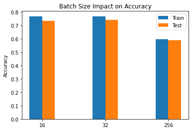

```python
labels = ["16", "32", "256"]
y_pos = np.arange(len(labels))
width = 0.2
plt.bar(y_pos - width/2, train_accuracies, width, label='Train')
plt.bar(y_pos + width/2, test_accuracies, width, label='Test')
plt.xticks(y_pos, labels)
plt.ylabel('Accuracy')
plt.title('Batch Size Impact on Accuracy')
plt.legend()
fig.tight_layout()
plt.show()
```

## Conclusion

In this Assignment I got familiar with Nueral Network and how they work. I saw how the forward pass and backward prpagation work and also how gradient descent works. I implemeted the formulas from scatch and employed them to classify the images. Also I saw how the hyperparameters can affect on the results.